# PM566 Lab Week 4

## 7. **Make a map showing the spatial trend in relative humidity in the US**

```r
met_avg2<-met_avg[!is.na(rh)]

# Top five
top5 <- met_avg2[rank(-rh) <= 10]

rh_pal = colorNumeric(c('blue','purple','red'), domain=met_avg2$rh)
leaflet(met_avg2) %>%
  addProviderTiles('OpenStreetMap') %>%
  addCircles(lat=~lat, lng=~lon, color=~rh_pal(rh), label=~paste0(round(rh,2), ' rh'), opacity=1,fillOpacity=1, radius=500) %>%
  addMarkers(lat=~lat, lng=~lon, label=~paste0(round(rh,2), ' rh'), data = top5) %>%
  addLegend('bottomleft',pal=rh_pal, values=met_avg2$rh, title="Relative Humidity", opacity=1)
```

[interactive chart not shown]

**Description**: The **East Coast and Southeast** are consistently humid, which can affect dew point, precipitation, and comfort levels. The **West,** however, is much drier, aligning with desert and Mediterranean climate zones. These RH patterns are crucial for modeling weather, understanding regional climate behavior, and even planning outdoor activities or athletic performance.

## 8. **Use a ggplot extension**

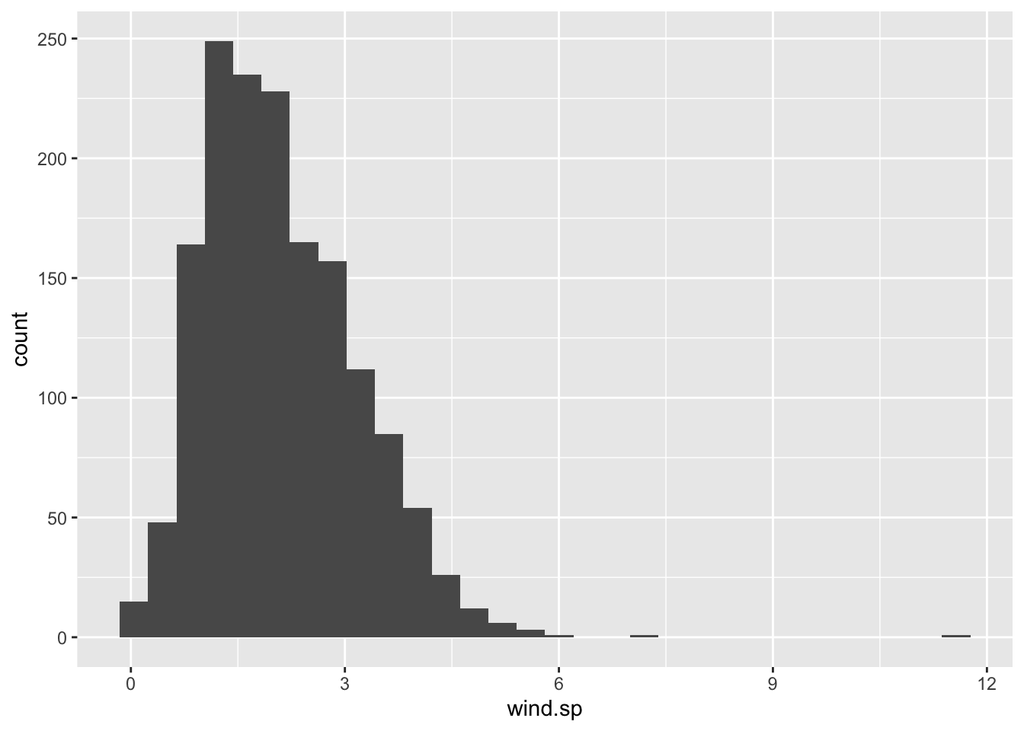

```r
ggplot(met_avg) +
  geom_histogram(mapping = aes(x = wind.sp))
```

**Description**: The **majority of wind speed values** fall between **0 and 5**, with the highest concentration near **2**—suggesting calm to moderate wind conditions are most common. The **long tail** extending toward higher values indicates **occasional strong winds**, but these are rare. The **right-skewed shape** implies that while low wind speeds dominate, the dataset includes some **extreme events** worth noting—possibly gusts or storm-related spikes.